# Лабораторная работа №01

Моделирование сетей передачи данных

бахи сиди али темассини

1032234211@rudn.ru

Российский университет дружбы народов

2026-09-12

# Информация

## Докладчик

- бахи сиди али темассини
- Российский университет дружбы народов

# Цель работы

- Изучить основные возможности среды Mininet.
- Создать простую сетевую топологию.
- Настроить IP-адреса хостов.
- Проверить связность между узлами.
- Освоить работу с графическим редактором MiniEdit.

# Выполнение лабораторной работы

## Запуск виртуальной машины Mininet

- Выполнен вход под пользователем `mininet`.
- Командой `ifconfig` проверены сетевые интерфейсы.
- Интерфейс `eth0`: `192.168.200.129`.
- Проверен локальный интерфейс `lo`.

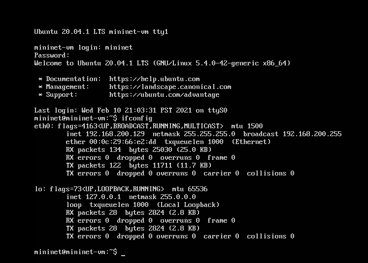

Рисунок 1: Проверка сетевых интерфейсов виртуальной машины Mininet

## Подключение по SSH

- Выполнено подключение с перенаправлением X11: `ssh -Y mininet@192.168.200.129`.
- Соединение с виртуальной машиной успешно установлено.

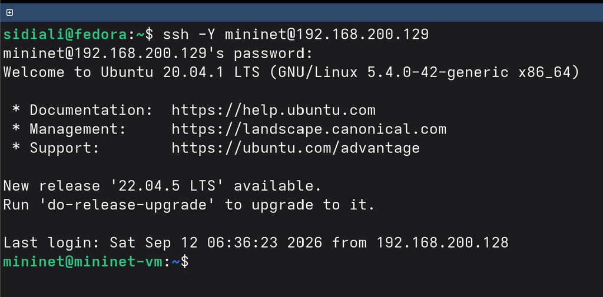

Рисунок 2: Подключение к виртуальной машине Mininet по протоколу SSH

## Настройка SSH-ключа

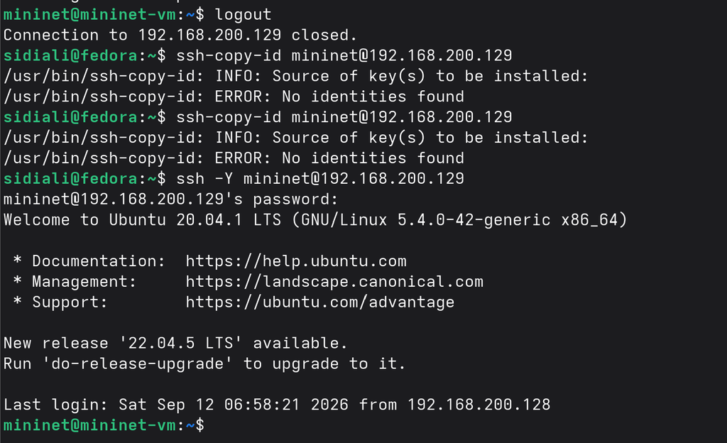

## Проверка сетевой конфигурации

- Повторно выполнена команда `ifconfig`.
- `eth0`: `192.168.200.129`.
- `lo`: `127.0.0.1`.

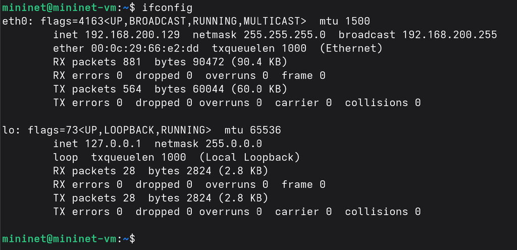

Рисунок 4: Проверка текущей конфигурации сетевых интерфейсов

## Настройка интерфейса eth1

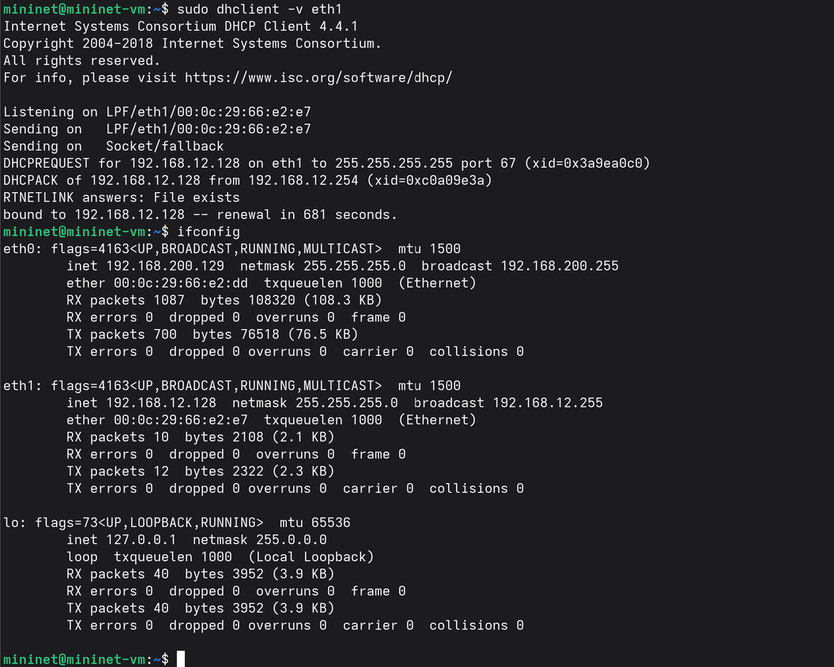

Рисунок 5: Получение IP-адреса для интерфейса eth1 по DHCP

## Установка Midnight Commander

- Установлен файловый менеджер `mc`.
- Установка выполнена командой `sudo apt install mc`.
- Необходимые зависимости установлены успешно.

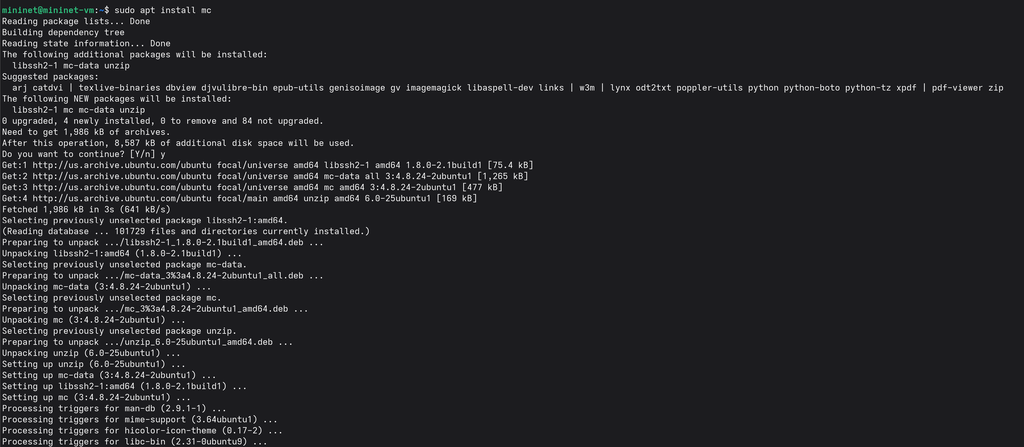

Рисунок 6: Установка файлового менеджера Midnight Commander в виртуальной машине

## Настройка Netplan

- Изменён файл `/etc/netplan/01-netcfg.yaml`.
- Для `eth0` и `eth1` включена автоматическая настройка IPv4 по DHCP.

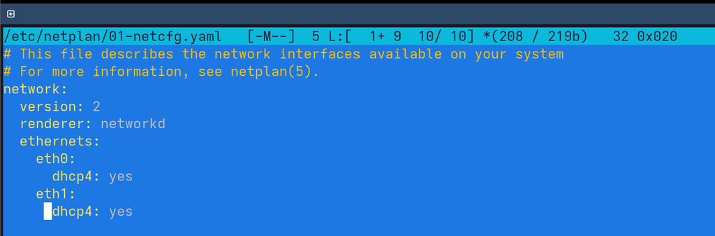

Рисунок 7: Настройка DHCP для сетевых интерфейсов eth0 и eth1

## Установка Mininet

- Исходный каталог переименован в `mininet.orig`.
- Исходный код Mininet клонирован повторно.
- Выполнена установка командой `sudo make install`.
- Версия Mininet: `2.3.1b4`.

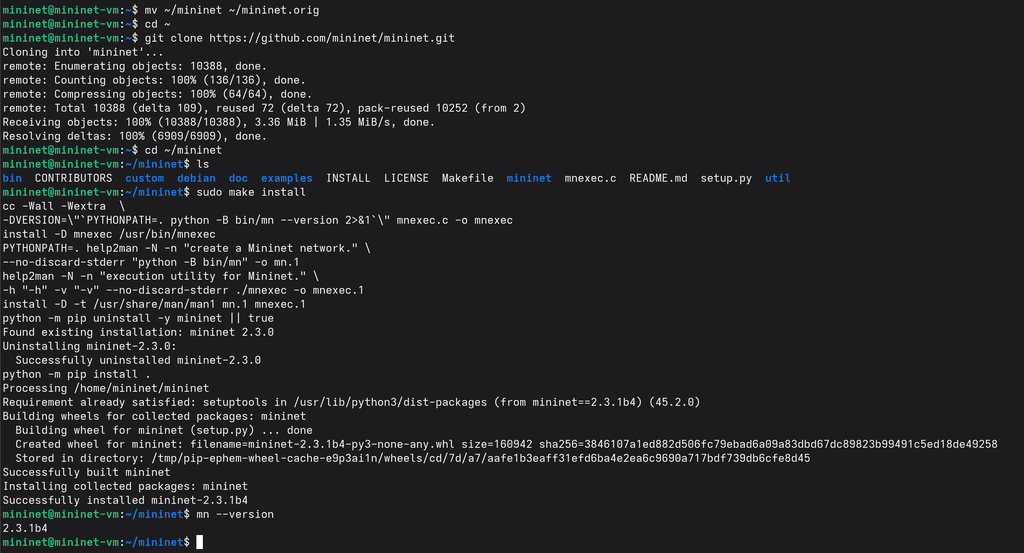

Рисунок 8: Установка Mininet из исходного кода и проверка версии

## Настройка терминала xterm

- В конфигурации `xterm` задан размер шрифта.
- Установлен параметр `xterm*faceSize: 12`.

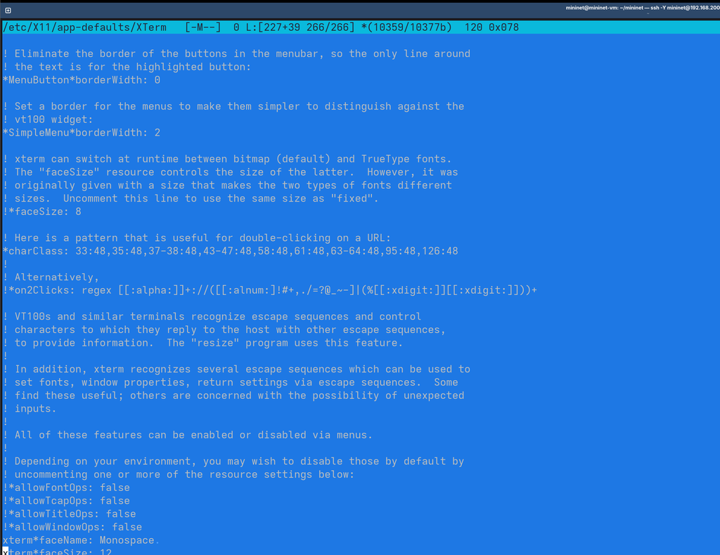

Рисунок 9: Настройка размера шрифта терминала xterm

## Настройка X11-аутентификации

- Получено значение `MIT-MAGIC-COOKIE-1`.
- Значение добавлено для пользователя `root`.
- Настройка проверена командой `xauth list $DISPLAY`.

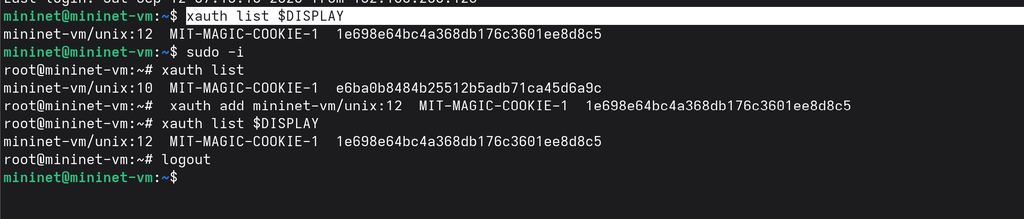

Рисунок 10: Настройка X11-аутентификации для пользователя root

## Запуск стандартной топологии Mininet

- Mininet запущен командой `sudo mn`.
- Созданы хосты `h1` и `h2`.
- Созданы коммутатор `s1` и контроллер `c0`.
- Командой `help` просмотрены доступные команды.

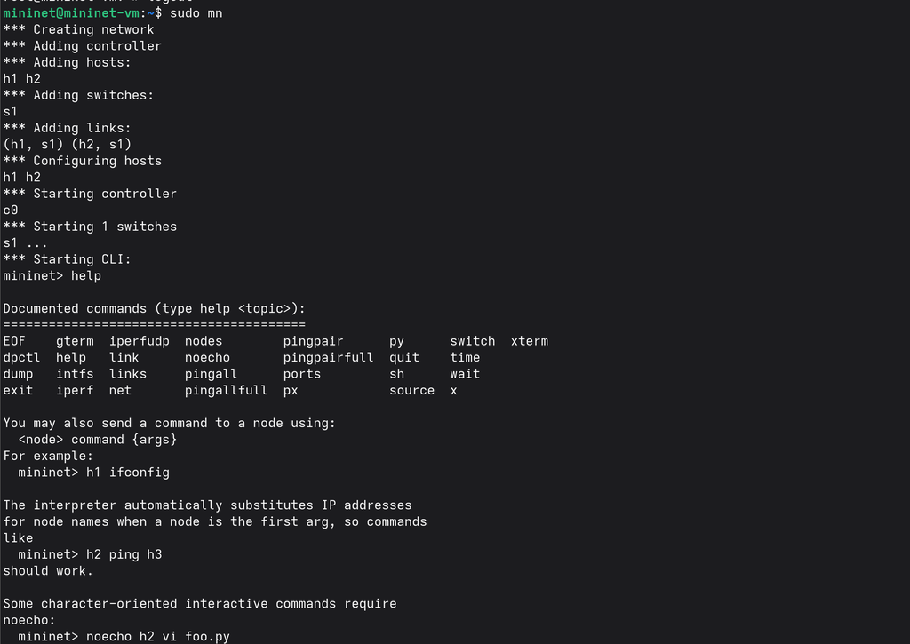

Рисунок 11: Запуск стандартной топологии и просмотр команд Mininet

## Проверка узлов и интерфейсов

- Командами `nodes` и `net` проверена топология.
- Хост `h1`: `10.0.0.1`.
- Хост `h2`: `10.0.0.2`.

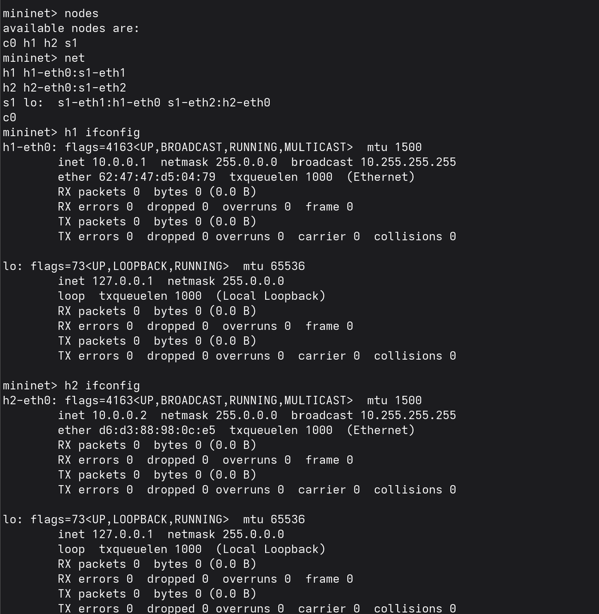

Рисунок 12: Проверка топологии и сетевых интерфейсов хостов Mininet

## Проверка связности хостов

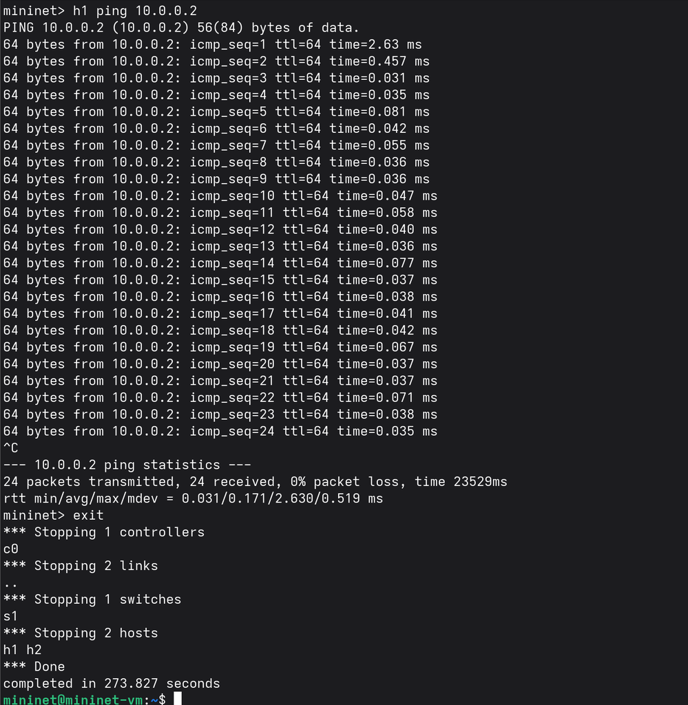

Рисунок 13: Проверка связности между хостами и завершение работы Mininet

## Запуск MiniEdit

- Запущен графический редактор MiniEdit.
- Открыто рабочее окно с пустой топологией.

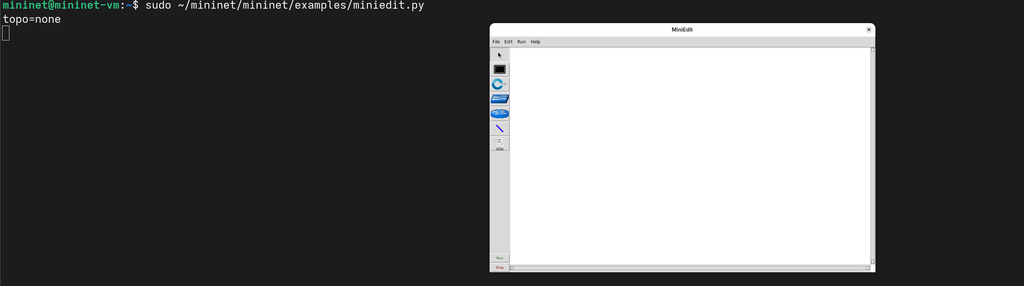

Рисунок 14: Запуск графического редактора топологий MiniEdit

## Создание топологии в MiniEdit

- Созданы два хоста: `h1` и `h2`.
- Добавлен коммутатор `s1`.
- Хосты соединены через коммутатор.

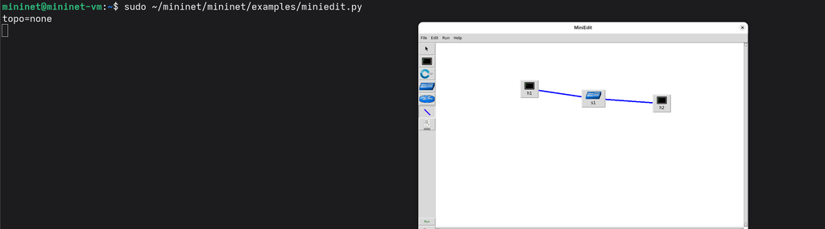

Рисунок 15: Топология сети из двух хостов и одного коммутатора в MiniEdit

## Настройка IP-адреса h1

- Открыты свойства хоста `h1`.
- Задан IP-адрес `10.0.0.1/8`.

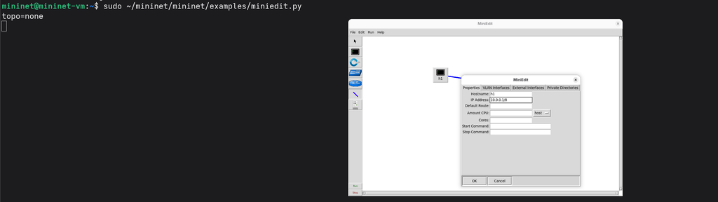

Рисунок 16: Настройка IP-адреса хоста h1 в MiniEdit

## Настройка IP-адреса h2

- Открыты свойства хоста `h2`.
- Задан IP-адрес `10.0.0.2/8`.

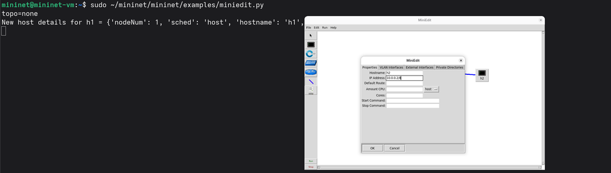

Рисунок 17: Настройка IP-адреса хоста h2 в MiniEdit

## Проверка топологии MiniEdit

- Запущена созданная топология.
- Проверены адреса командой `ifconfig`.
- Выполнен взаимный `ping` между `h1` и `h2`.
- Пакеты переданы без потерь.

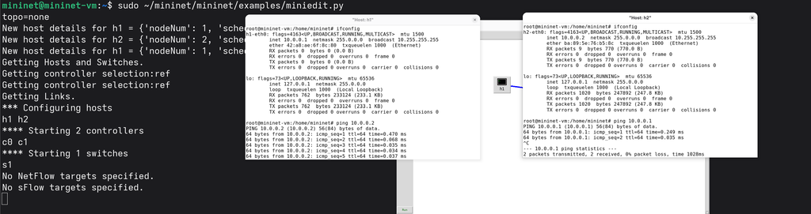

Рисунок 18: Проверка IP-адресов и связности хостов созданной топологии

## Удаление IP-адресов хостов `h1`

- Удалён вручную заданный IP-адрес хоста `h1`.
- Поле `IP Address` оставлено пустым.

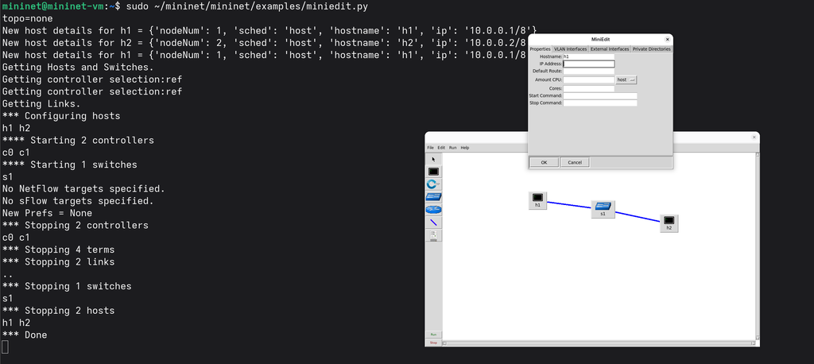

Рисунок 19: Удаление вручную заданного IP-адреса хоста h1

## Удаление IP-адресов хостов `h2`

- Удалён вручную заданный IP-адрес хоста `h2`.
- Поле `IP Address` оставлено пустым.

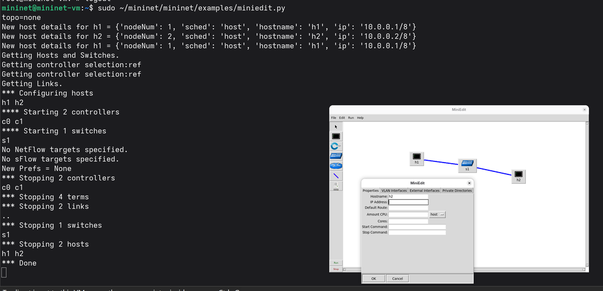

Рисунок 20: Удаление вручную заданного IP-адреса хоста h2

## Настройка IP Base

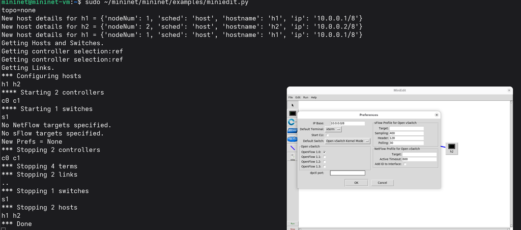

## Проверка автоматической адресации

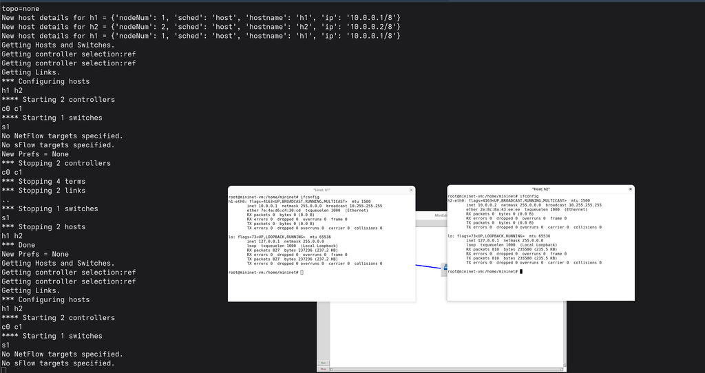

Рисунок 22: Проверка автоматически назначенных IP-адресов хостов h1 и h2

## Сохранение топологии

- Подготовлен рабочий каталог `~/work`.
- Топология сохранена в файл `lab01.mn`.

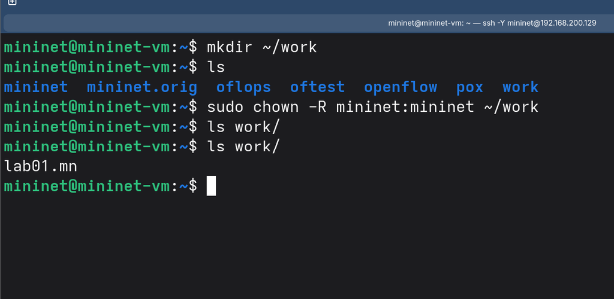

Рисунок 23: Проверка сохранённого файла топологии lab01.mn в рабочем каталоге

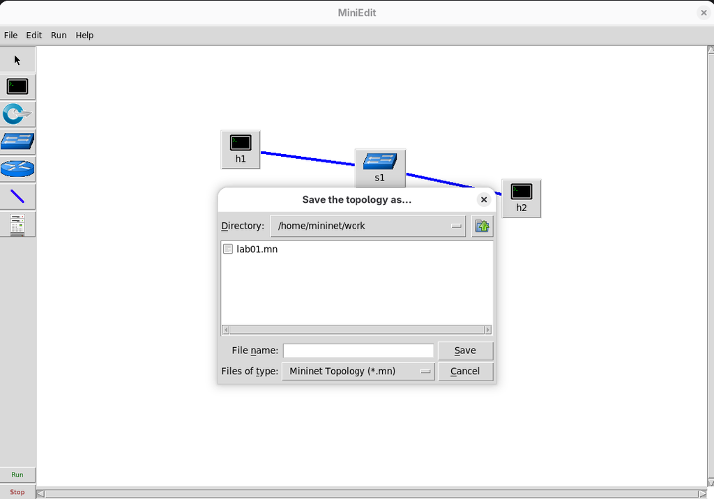

## Проверка загруженной топологии

- Файл `lab01.mn` успешно загружен.
- Восстановлены хосты `h1` и `h2`.
- Восстановлен коммутатор `s1`.
- Восстановлены соединения между узлами.

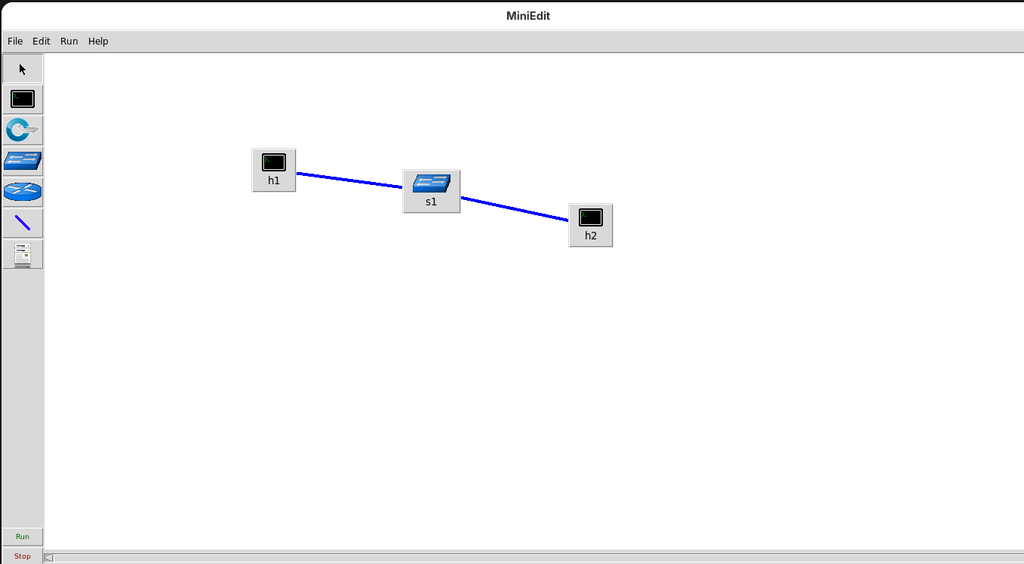

Рисунок 25: Загруженная из файла lab01.mn топология сети в MiniEdit

# Заключение

- Подготовлена среда Mininet.
- Создана топология из двух хостов и одного коммутатора.
- Проверены сетевые интерфейсы и связность хостов.
- Создана аналогичная топология в MiniEdit.
- IP-адреса настроены вручную и через `IP Base`.
- Топология сохранена в файл `lab01.mn`.
- Проверена повторная загрузка сохранённой топологии.